# Felfedező adatelemzés

[Az R Notebookról bővebben](https://bookdown.org/yihui/rmarkdown/notebook.html)

Töltsünk be egy pár csomagot!

```r
library(tidyverse)
library(plotly)
library(htmlwidgets)
library(GGally)
library(gridExtra)
library(corrplot)
library(plotly)
library(htmlwidgets)
```

# Miről szól a felfedező adatelemzés?

Az a cél, hogy elkezdjük érteni az adatokat.

Kreatív folyamat, hagyatkozzunk a megérzéseinkre (is),

1. Találj ki kérdéseket az adatokkal kapcsolatban!
2. Próbáld megválaszolni őket ábrázolások, transzformációk, és modellek által!
3. Ezek fényében finomítsd a kérdéseket, és tegyél fel újakat!

Érdemes jó sok kérdéssel indítani, aztán majd elválik, hogy melyikkel mennyit érdemes foglalkozni

Nincsenek szigorúan értelmezett szabályok, két kérdés viszont általában érdekes:

- milyen a változók variabilitása?
- milyen a változók közös varianciája?

## Változók variabilitásának vizsgálata

Eloszlások megjelenítése

Kategorikus változók: oszlopdiagram

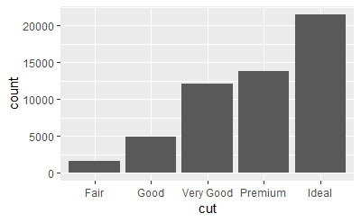

```r
ggplot(data = diamonds) +
  geom_bar(mapping = aes(x = cut))
```

Oszlopok magassága *x* lehetséges értékeinek darabszámát mutatja

```r
diamonds %>%
  count(cut)
```

| cut | n |
| --- | --- |
| Fair | 1610 |
| Good | 4906 |
| Very Good | 12082 |
| Premium | 13791 |
| Ideal | 21551 |

Folytonos változók eloszlását pedig megnézhetjük mondjuk egy hisztogramon

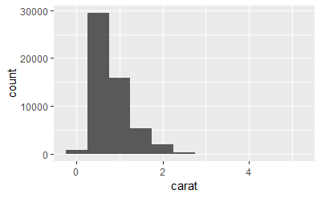

```r
ggplot(data = diamonds) +
  geom_histogram(mapping = aes(x = carat), binwidth = 0.5)
```

A megjelenített értékek kiszámolása

```r
diamonds %>%
  count(cut_width(carat, 0.5))
```

| cut_width(carat, 0.5) | n |
| --- | --- |
| [-0.25,0.25] | 785 |
| (0.25,0.75] | 29498 |
| (0.75,1.25] | 15977 |
| (1.25,1.75] | 5313 |
| (1.75,2.25] | 2002 |
| (2.25,2.75] | 322 |
| (2.75,3.25] | 32 |
| (3.25,3.75] | 5 |
| (3.75,4.25] | 4 |
| (4.25,4.75] | 1 |

[output cut: 1 more lines]

geom_histogram binwidth argumentuma mondja meg, hogy az x változót mekkora intervallumokra szabdaljuk fel az ábrázoláshoz - érdemes kipróbálni több értéket! Pl. csak a három karátnál kisebb gyémántok, keskenyebb binekkel:

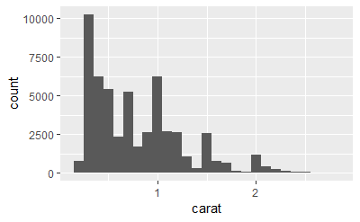

```r
smaller <- diamonds %>%
  filter(carat < 3)
ggplot(data = smaller, mapping = aes(x = carat)) +
  geom_histogram(binwidth = 0.1)
```

Ugyanez szétdobva csiszolás szerint fazettákra

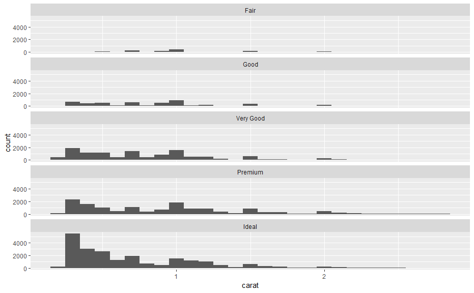

```r
ggplot(data = smaller, mapping = aes(x = carat)) +
  geom_histogram(binwidth = 0.1) +
  facet_wrap(~ cut, nrow = 5)
```

Ha több kategória eloszlását egy ábrán akarjuk mutatni, rajzoljunk inkább vonalakat!

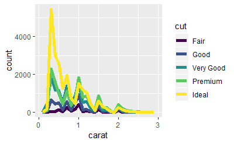

```r
ggplot(data = smaller, mapping = aes(x = carat, colour = cut)) +
  geom_freqpoly(binwidth = 0.1, size = 2)
```

Mire érdemes figyelni?

- Mik a leggyakoribb értékek? Miért?
- Mik a legritkább értékek? Miért? Erre számítottunk?
- Szokatlan, különös mintázatok? Mi lehet az oka?

Mi az érdekes ezen az ábrán?

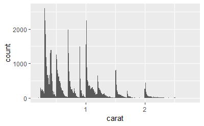

```r
ggplot(data = smaller, mapping = aes(x = carat)) +
  geom_histogram(binwidth = 0.01)
```

És ezen?

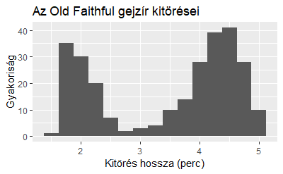

```r
ggplot(data = faithful, mapping = aes(x = eruptions)) +
  geom_histogram(binwidth = 0.25) +
  xlab("Kitörés hossza (perc)") +
  ylab("Gyakoriság") +
  ggtitle("Az Old Faithful gejzír kitörései")
```

Klaszterekbe tömörülő hasonló értékek alcsoportokra utalhatnak.

- Milyen szempontból hasonlóak egymáshoz az egy csoportba tartozó megfigyelések?
- Milyen szempontból különböznek egymástól a külön csoportokba tartozó megfigyelések?
- Hogyan lehetne jellemezni a klasztereket?
- Miért lehet félrevezető a klaszterek jelenléte?

Szokatlan értékek (outlier)

Több oka is lehet! - adatrögzítési hiba - váratlan és informatív megfigyelés

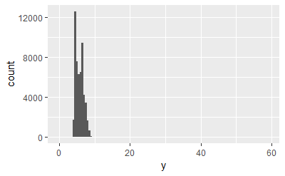

```r
ggplot(diamonds) +
  geom_histogram(mapping = aes(x = y), binwidth = 0.5)
```

Hol van itt az outlier? Közelítsünk rá az ábrára!

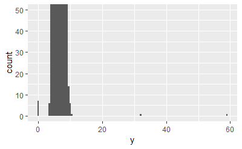

```r
ggplot(diamonds) +
  geom_histogram(mapping = aes(x = y), binwidth = 0.5) +
  coord_cartesian(ylim = c(0, 50))
```

Nézzük meg jobban ezeket a megfigyeléseket!

```r
(unusual <- diamonds %>%
  filter(y < 3 | y > 20) %>%
  select(price, x, y, z) %>%
  arrange(y))
```

| price | x | y | z |
| --- | --- | --- | --- |
| 5139 | 0.00 | 0.0 | 0.00 |
| 6381 | 0.00 | 0.0 | 0.00 |
| 12800 | 0.00 | 0.0 | 0.00 |
| 15686 | 0.00 | 0.0 | 0.00 |
| 18034 | 0.00 | 0.0 | 0.00 |
| 2130 | 0.00 | 0.0 | 0.00 |
| 2130 | 0.00 | 0.0 | 0.00 |
| 2075 | 5.15 | 31.8 | 5.12 |
| 12210 | 8.09 | 58.9 | 8.06 |

Gondoljuk végig alaposan: mi okozhatta ezeket az anomáliákat?

## Gyakorlás - eloszlások ábrázolása

1. Vizsgáld meg a price változó eloszlását! Észreveszel-e valami furát?

## Hiányzó értékek

Mit tegyünk ezekkel a furcsa gyémántokkal?

1. eldobhatjuk őket

```r
diamonds2 <- diamonds %>%
  filter(between(y, 3, 20))
```

Miért nem szerencsés?

2. a furcsa értékeiket átírjuk hiányzóra

```r
diamonds2 <- diamonds %>%
  mutate(y = ifelse(y < 3 | y > 20, NA, y))
```

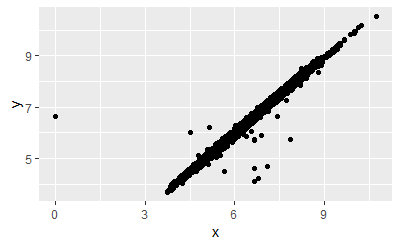

```r
ggplot(data = diamonds2, mapping = aes(x = x, y = y)) +
  geom_point()
```

ggplot2 figyelmeztet az NA-kra

De az is lehet, hogy pont a hiányzó értékeket tartalmazó megfigyelések érdekesek Pl. mikor kellett volna indulniuk a törölt járatoknak?

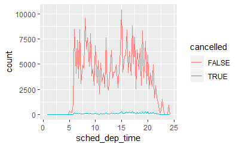

```r
nycflights13::flights %>%
  mutate(
    cancelled = is.na(dep_time),
    sched_hour = sched_dep_time %/% 100,
    sched_min = sched_dep_time %% 100,
    sched_dep_time = sched_hour + sched_min / 60
  ) %>%
  ggplot(mapping = aes(sched_dep_time)) +
  geom_freqpoly(mapping = aes(colour = cancelled), binwidth = 1/4)
```

Miért nem túl informatív ez az ábra?

## Változók közös varianciája

Kategorikus vs. folytonos

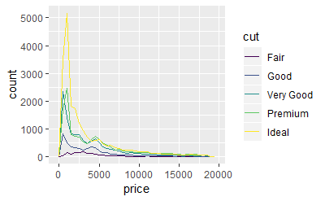

```r
ggplot(data = diamonds, mapping = aes(x = price)) +
  geom_freqpoly(mapping = aes(colour = cut), binwidth = 500)
```

A gyakoriságokban nagy eltérések vannak, ezért nem látszik jól, hogy különbözik-e a különböző csiszolású gyémántok eloszlása

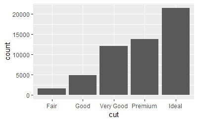

```r
ggplot(diamonds) +
  geom_bar(mapping = aes(x = cut))
```

Ilyenkor darabszám helyett érdemes a sűrűséget mutatni:

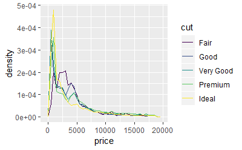

```r
ggplot(data = diamonds, mapping = aes(x = price, y = ..density..)) +
  geom_freqpoly(mapping = aes(colour = cut), binwidth = 500)
```

Vagy használhatunk boxplotot is

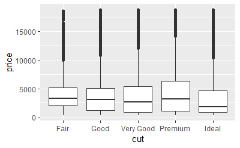

```r
ggplot(data = diamonds, mapping = aes(x = cut, y = price)) +
  geom_boxplot()
```

A rosszabb minőségű gyémántok drágábbak lennének?

A vágások egyértelműen rangsorolhatóak. De nem minden kategorikus változó ordinális. Vegyük például a különböző típusú autók fogyasztását.

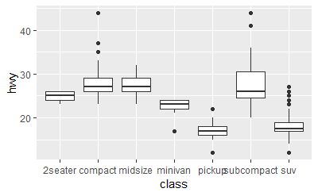

```r
ggplot(data = mpg, mapping = aes(x = class, y = hwy)) +
  geom_boxplot()
```

Az ábra áttekinthetőbb lehet, ha a fogyasztás mediánja szerint sorbarendezzük a kategóriákat

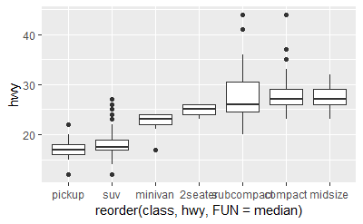

```r
ggplot(data = mpg) +
  geom_boxplot(mapping = aes(x = reorder(class, hwy, FUN = median), y = hwy))
```

Ha hosszúak a változónevek, forgassunk egyet az ábrán:

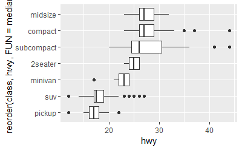

```r
ggplot(data = mpg) +
  geom_boxplot(mapping = aes(x = reorder(class, hwy, FUN = median), y = hwy)) +
  coord_flip()
```

Hogyan javíthatnánk akkor ezen az ábrán az eddigiek fényében?

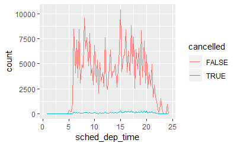

```r
nycflights13::flights %>%
  mutate(
    cancelled = is.na(dep_time),
    sched_hour = sched_dep_time %/% 100,
    sched_min = sched_dep_time %% 100,
    sched_dep_time = sched_hour + sched_min / 60
  ) %>%
  ggplot(mapping = aes(sched_dep_time)) +
  geom_freqpoly(mapping = aes(colour = cancelled), binwidth = 1/4)
```

Kategorikus vs. kategorikus

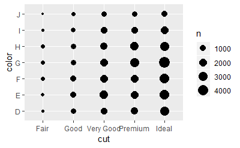

```r
ggplot(data = diamonds) +
  geom_count(mapping = aes(x = cut, y = color))
```

Az ábrához tartozó gyakorisági tábla

```r
diamonds %>%
  count(color, cut)
```

| color | cut | n |
| --- | --- | --- |
| D | Fair | 163 |
| D | Good | 662 |
| D | Very Good | 1513 |
| D | Premium | 1603 |
| D | Ideal | 2834 |
| E | Fair | 224 |
| E | Good | 933 |
| E | Very Good | 2400 |
| E | Premium | 2337 |
| E | Ideal | 3903 |

[output cut: 25 more lines]

Ugyanezt megmutathatjuk egy szép hőtérképen is

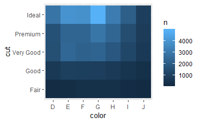

```r
diamonds %>%
  count(color, cut) %>%
  ggplot(mapping = aes(x = color, y = cut)) +
  geom_tile(mapping = aes(fill = n))
```

Folytonos vs. folytonos

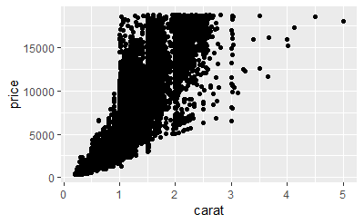

```r
ggplot(data = diamonds) +
  geom_point(mapping = aes(x = carat, y = price))
```

Hátha többet látunk, ha áttetszővé tesszük a pontokat

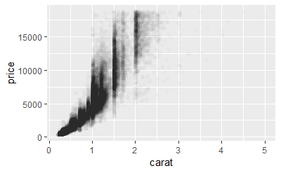

```r
ggplot(data = diamonds) +
  geom_point(mapping = aes(x = carat, y = price), alpha = 1 / 100)
```

Nagy adathalmazokon nem mindig segít az áttetszőség szabályzása Ilyenkor binekre is oszthatjuk az adatokat

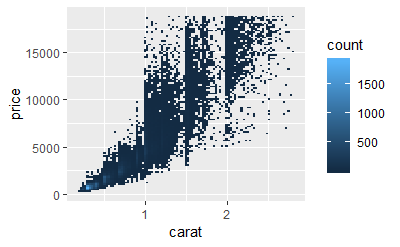

```r
ggplot(data = smaller) +
  geom_bin2d(mapping = aes(x = carat, y = price), bins = 100)
```

Készíthetünk boxplotot is:

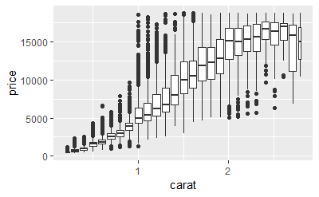

```r
ggplot(data = smaller, mapping = aes(x = carat, y = price)) +
  geom_boxplot(mapping = aes(group = cut_width(carat, 0.1)))
```

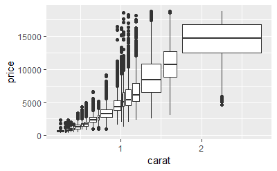

```r
ggplot(data = smaller, mapping = aes(x = carat, y = price)) +
  geom_boxplot(mapping = aes(group = cut_number(carat, 20)))
```

# Gyors adatfelfedezés

## GGally

Változók eloszlása és kapcsolata egy nagy ábrán, egyetlen sor kóddal

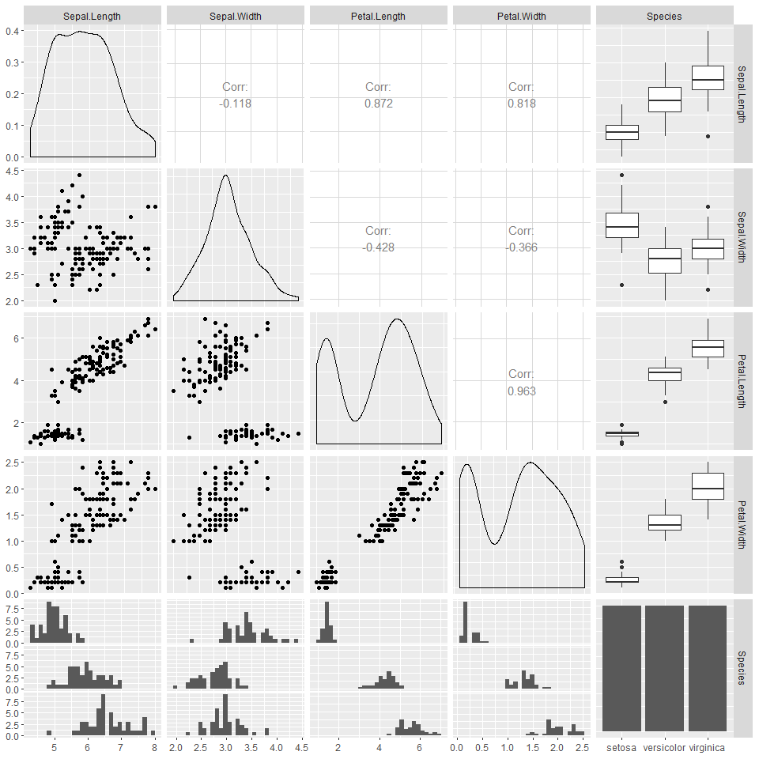

```r
ggpairs(iris, progress=FALSE)
```

Érdemes tudni a base graphics pairs() függvényéről is: kevésbé látványos, viszont jóval gyorsabb

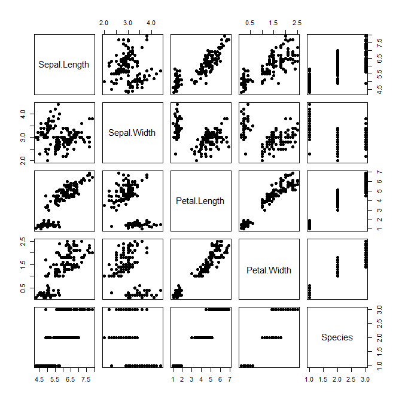

```r
pairs(iris, pch=16)
```

[Egyéb pontfelhő-mátrix lehetőségek](http://www.sthda.com/english/wiki/scatter-plot-matrices-r-base-graphs#r-base-scatter-plot-matrices-pairs)

Hasznos lehet még a ggcoef() egy modell együtthatóinak gyors áttekintéséhez

Nézzünk egy példát!

Mivel függ össze a fogyasztás?

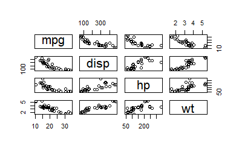

```r
mtcars %>%
  select(mpg, disp, hp, wt) %>%
  pairs()
```

Illesszünk többszörös lineáris regresziós modellt, és nézzük meg az eredményeket!

```r
model <-
  mtcars %>%
  select(mpg, disp, hp, wt) %>%
  # standardizáljuk a változókat, hogy standardizált együtthatókat kapjunk
  mutate_all(scale) %>%
  lm(mpg ~  ., data = .)
summary(model)
```

```
Call:
lm(formula = mpg ~ ., data = .)

Residuals:
     Min       1Q   Median       3Q      Max
-0.64562 -0.27212 -0.02854  0.17607  0.97245

Coefficients:
              Estimate Std. Error t value Pr(>|t|)
(Intercept)  3.568e-17  7.740e-02   0.000  1.00000
disp        -1.927e-02  2.128e-01  -0.091  0.92851
hp          -3.544e-01  1.301e-01  -2.724  0.01097 *
wt          -6.171e-01  1.731e-01  -3.565  0.00133 **
---
Signif. codes:  0 ‘***’ 0.001 ‘**’ 0.01 ‘*’ 0.05 ‘.’ 0.1 ‘ ’ 1

Residual standard error: 0.4379 on 28 degrees of freedom
Multiple R-squared:  0.8268,    Adjusted R-squared:  0.8083
F-statistic: 44.57 on 3 and 28 DF,  p-value: 8.65e-11
```

```r
confint(model)
```

```
                 2.5 %      97.5 %
(Intercept) -0.1585520  0.15855201
disp        -0.4552375  0.41670004
hp          -0.6209244 -0.08795267
wt          -0.9716283 -0.26249869
```

Mindezt ábrázolhatjuk is

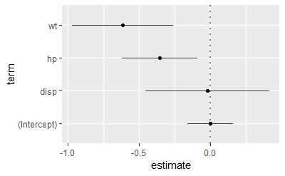

```r
ggcoef(model)
```

## corrplot

Korrelációs mátrixok ábrázolása

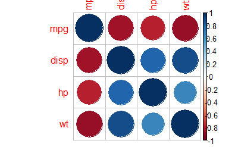

```r
mtcars %>%
  select(mpg, disp, hp, wt) %>%
  cor() %>% # korrelációs mátrix
  corrplot()
```

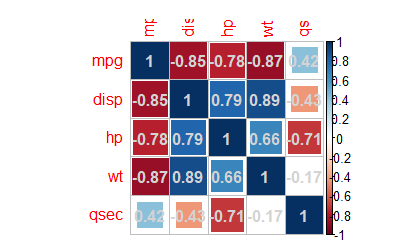

```r
p_mat <-
  mtcars %>%
  select(mpg, disp, hp, wt, qsec) %>%
  cor.mtest() %>% .[["p"]] # kinyerjük a korrelációkhoz tartozó
mtcars %>%
  select(mpg, disp, hp, wt, qsec) %>%
  cor() %>% # korrelációs mátrix
  corrplot(p.mat       = p_mat,
           method      = "square",
           addCoef.col = "lightgrey",
           mar         = c(0.2,1,1,0.5),
           insig       = "blank")
```

[További beállítási lehetőségek a corrplot-ban](https://cran.r-project.org/web/packages/corrplot/vignettes/corrplot-intro.html)

# Több panelből álló ábrák

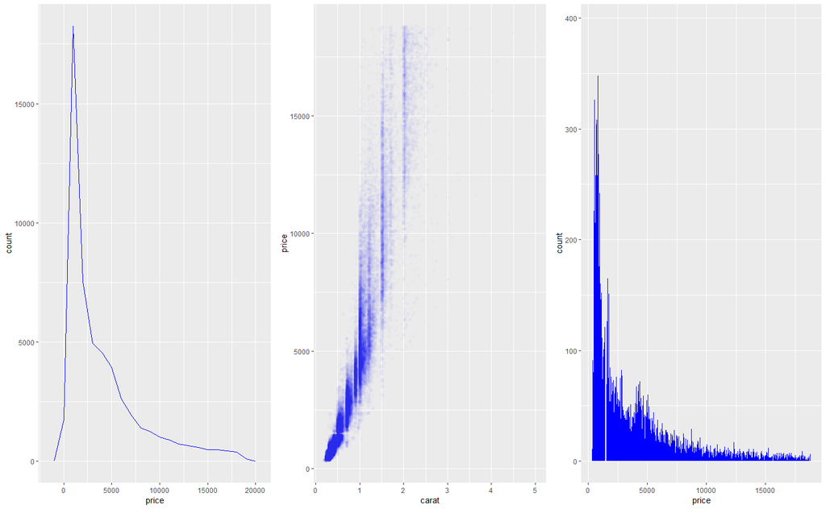

```r
p1 <- ggplot(diamonds) +
  geom_freqpoly(aes(price), col="blue",binwidth = 1000)
p2 <- ggplot(diamonds) +
  geom_point(aes(carat, price), alpha = 0.01, col="blue")
p3 <- ggplot(diamonds) +
  geom_histogram(aes(price), fill="blue", binwidth = 10)
grid.arrange(p1, p2, p3, nrow = 1)
```

Ábrák elrendezésének finomhangolása

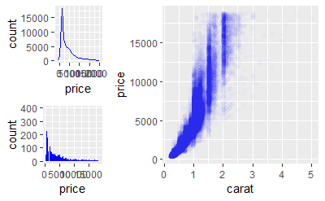

```r
grid.arrange(p1, p2, p3,
             layout_matrix = rbind(c(1, 2, 2),
                                   c(3, 2, 2))
             )
```

[További lehetőségek több panelből álló ábrák szerkesztésére](https://cran.r-project.org/web/packages/egg/vignettes/Ecosystem.html)